# STAT3102 Week 3 SGTA Report

Seo Yeon Pyo

2026-10-10

# Overview

This report completes the exercises for **STAT3102/6102 Week 3 SGTA**, focusing on categorical visualization techniques (pie charts, standard bar charts, and Pareto charts) and continuous distribution analysis (histograms, bin width exploration, and comparative boxplots).

# Exercise 1: Categorical Data Visualisations (`stat270.csv`)

Recall that the dataset `stat270.csv` contains three variables: `ID`, `Country`, and `Statdiv` (Statistical Division). Here, we construct pie charts, ordered bar charts, and Pareto charts for the `Statdiv` variable.

```r
# Read stat270 dataset
stat270 <- read_csv("stat270.csv")

# Standardise column names to lowercase so Statdiv becomes statdiv
colnames(stat270) <- tolower(colnames(stat270))

# Clean and summarise statistical division counts
df_statdiv <- stat270 %>%
  filter(!is.na(statdiv)) %>%
  count(statdiv, name = "counts") %>%
  mutate(percentage = round(counts / sum(counts) * 100, 1))
```

### 1. Pie Chart

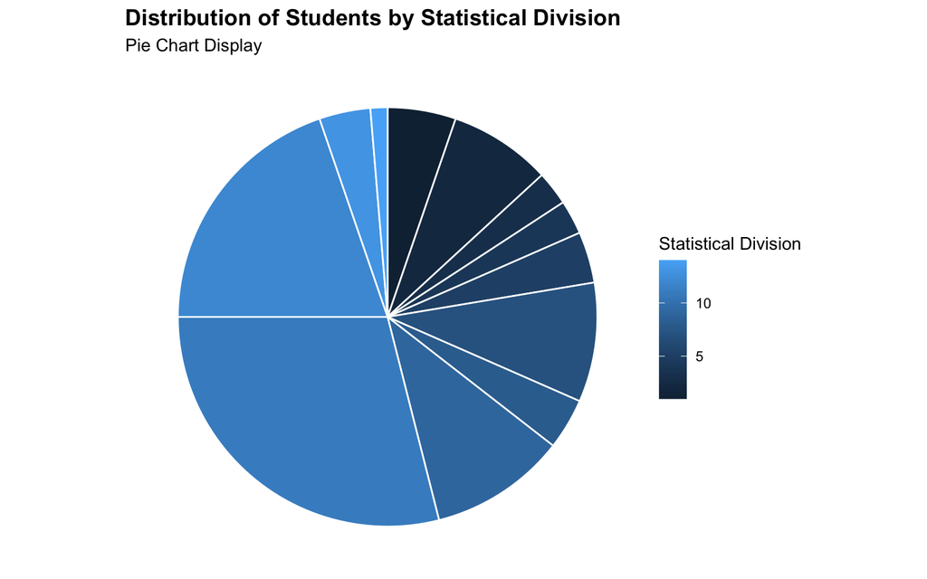

```r
ggplot(df_statdiv, aes(x = "", y = counts, fill = statdiv)) +
  geom_bar(stat = "identity", width = 1, color = "white") +
  coord_polar(theta = "y") +
  theme_void() +
  labs(
    title = "Distribution of Students by Statistical Division",
    subtitle = "Pie Chart Display",
    fill = "Statistical Division"
  ) +
  theme(plot.title = element_text(face = "bold", size = 14))
```

### 2. Standard & Ordered Bar Chart (Pareto Chart)

Ordering the categories by frequency creates a **Pareto Chart**, applying Cleveland’s principle of position along a common scale and adhering to Wainer’s rule against arbitrary orderings.

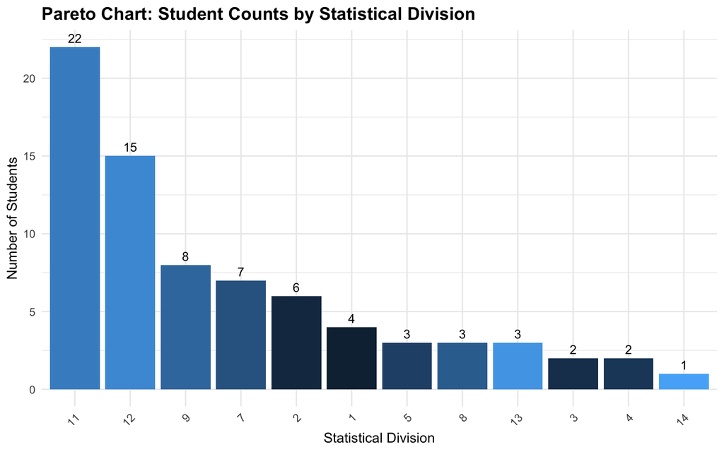

```r
ggplot(df_statdiv, aes(x = reorder(statdiv, -counts), y = counts, fill = statdiv)) +
  geom_col(show.legend = FALSE) +
  geom_text(aes(label = counts), vjust = -0.5, size = 3.5) +
  theme_minimal() +
  labs(
    title = "Pareto Chart: Student Counts by Statistical Division",
    x = "Statistical Division",
    y = "Number of Students"
  ) +
  theme(
    axis.text.x = element_text(angle = 45, hjust = 1, size = 9),
    plot.title = element_text(face = "bold", size = 14)
  )
```

# Exercise 2: Australian Prison Population Analysis (ABS 2024)

```r
# Construct prisoners tibble as specified
prisoners <- tibble(
  Offence = c(
    "Homicide", "Acts to Cause Injury", "Sexual Assault", "Dangerous/Negligent Acts",
    "Abduction/Harassment", "Robbery/Extortion", "Unlawful Entry", "Theft",
    "Fraud/Deception", "Illicit Drugs", "Weapons/Explosives", "Property Damage",
    "Public Order", "Traffic/Vehicle", "Offences Against Justice", "Miscellaneous"
  ),
  total_males = c(3061, 11335, 7244, 1413, 610, 2332, 3434, 1302, 437, 4663, 826, 558, 138, 338, 3104, 71),
  total_females = c(298, 980, 111, 119, 45, 239, 327, 225, 127, 550, 46, 70, 11, 36, 239, 10)
)

# Reshape data to long format for side-by-side ggplot visualisations
prisoners_long <- prisoners %>%
  pivot_longer(
    cols = c(total_males, total_females),
    names_to = "Sex",
    names_prefix = "total_",
    values_to = "Count"
  ) %>%
  mutate(Sex = ifelse(Sex == "males", "Males", "Females"))
```

### Side-by-Side Comparative Bar Chart

Comparing total male and female prisoner counts across major offence types:

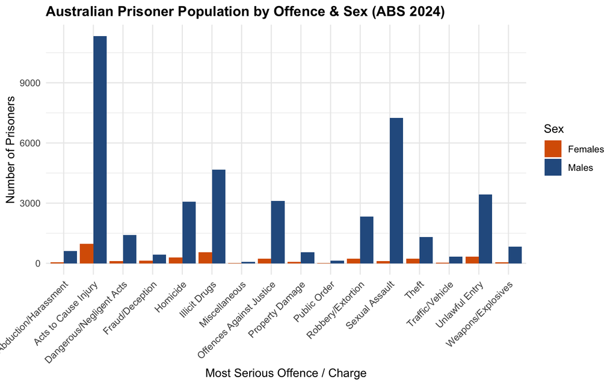

```r
ggplot(prisoners_long, aes(x = Offence, y = Count, fill = Sex)) +
  geom_col(position = "dodge") +
  scale_fill_manual(values = c("Males" = "#2b5c8f", "Females" = "#d95f02")) +
  theme_minimal() +
  labs(
    title = "Australian Prisoner Population by Offence & Sex (ABS 2024)",
    x = "Most Serious Offence / Charge",
    y = "Number of Prisoners",
    fill = "Sex"
  ) +
  theme(
    axis.text.x = element_text(angle = 45, hjust = 1, size = 9),
    plot.title = element_text(face = "bold", size = 13)
  )
```

### Comparative Pareto Chart (Ordered by Offence Volume)

Sorting offences by total volume facilitates clearer visual evaluation of high-frequency offences.

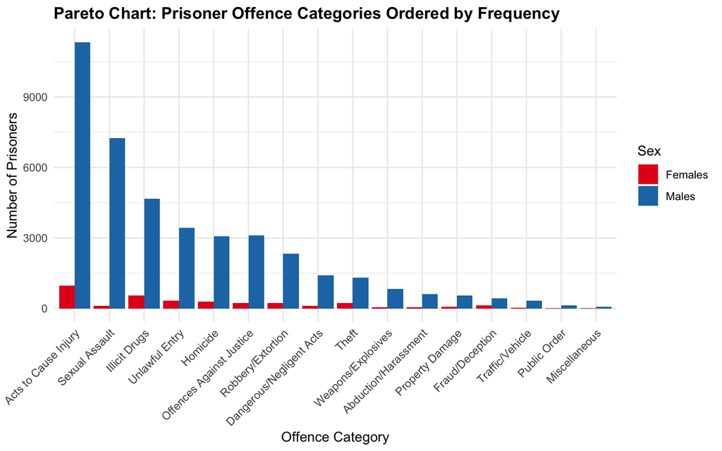

```r
# Sort offences by combined total
prisoners_long <- prisoners_long %>%
  group_by(Offence) %>%
  mutate(Total_Offence = sum(Count)) %>%
  ungroup()

ggplot(prisoners_long, aes(x = reorder(Offence, -Total_Offence), y = Count, fill = Sex)) +
  geom_col(position = "dodge") +
  scale_fill_manual(values = c("Males" = "#1f78b4", "Females" = "#e31a1c")) +
  theme_minimal() +
  labs(
    title = "Pareto Chart: Prisoner Offence Categories Ordered by Frequency",
    x = "Offence Category",
    y = "Number of Prisoners",
    fill = "Sex"
  ) +
  theme(
    axis.text.x = element_text(angle = 45, hjust = 1, size = 9),
    plot.title = element_text(face = "bold", size = 13)
  )
```